# P8105 Homework 6 Solutions

Meghan Bellerose

December 5, 2020

```r
library(tidyverse)
library(modelr)
library(mgcv)

knitr::opts_chunk$set(
  fig.width = 6,
  fig.asp = .6,
  out.width = "90%"
)

theme_set(theme_minimal() + theme(legend.position = "bottom"))

options(
  ggplot2.continuous.colour = "viridis",
  ggplot2.continuous.fill = "viridis"
)

scale_colour_discrete = scale_colour_viridis_d
scale_fill_discrete = scale_fill_viridis_d

set.seed(1)
```

# Problem 1

```r
homicide_df =
  read_csv("./data/homicide-data.csv") %>%
  mutate(
    city_state = str_c(city, state, sep = ", "),
    victim_age = as.numeric(victim_age),
    resolution = case_when(
      disposition == "Closed without arrest" ~ 0,
      disposition == "Open/No arrest"        ~ 0,
      disposition == "Closed by arrest"      ~ 1,
    )
  ) %>%
  filter(city_state != "Tulsa, AL",
         victim_race %in% c("White", "Black")) %>%
  select(city_state, resolution, victim_age, victim_race, victim_sex)
```

Start with one city.

```r
baltimore_df =
  homicide_df %>%
  filter(city_state == "Baltimore, MD")
glm(resolution ~ victim_age + victim_race + victim_sex,
    data = baltimore_df,
    family = binomial()) %>%
  broom::tidy() %>%
  mutate(
    OR = exp(estimate),
    CI_lower = exp(estimate - 1.96 * std.error),
    CI_upper = exp(estimate + 1.96 * std.error)
  ) %>%
  select(term, OR, starts_with("CI")) %>%
  knitr::kable(digits = 3)
```

| term | OR | CI_lower | CI_upper |
| --- | --- | --- | --- |
| (Intercept) | 1.363 | 0.975 | 1.907 |
| victim_age | 0.993 | 0.987 | 1.000 |
| victim_raceWhite | 2.320 | 1.648 | 3.268 |
| victim_sexMale | 0.426 | 0.325 | 0.558 |

Try this across cities.

```r
model_results_df =
  homicide_df %>%
  nest(data = -city_state) %>%
  mutate(
    models =
      map(.x = data,
          ~glm(resolution ~ victim_age + victim_race + victim_sex,
            data = .x,
            family = binomial())),
    results = map(models, broom::tidy)
  ) %>%
  select(city_state, results) %>%
  unnest(results) %>%
  mutate(
    OR = exp(estimate),
    CI_lower = exp(estimate - 1.96 * std.error),
    CI_upper = exp(estimate + 1.96 * std.error)
  ) %>%
   select(city_state, term, OR, starts_with("CI"))
```

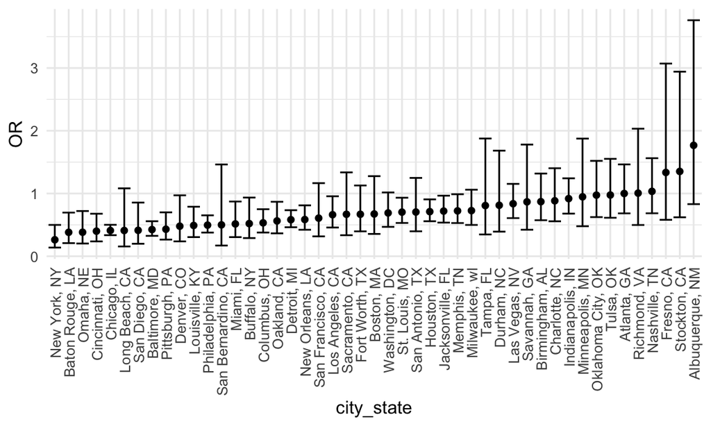

```r
model_results_df %>%
  filter(term == "victim_sexMale") %>%
  mutate(city_state = fct_reorder(city_state, OR)) %>%
  ggplot(aes(x = city_state, y = OR)) +
  geom_point() +
  geom_errorbar(aes(ymin = CI_lower, ymax = CI_upper)) +
  theme(axis.text.x = element_text(angle = 90, hjust = 1, vjust = 0.6))
```

# Problem 2

This problem uses data on children’s birth weights. In the following code chunks, I show the process I used to come up with a linear regression model with the outcome birth weight `btw`.

#### Fitting a model

**1. Load and clean the dataset for regression analysis**

```r
birthweight_df =
  read_csv("./data/birthweight.csv") %>%
  mutate(
    mrace = as.character(mrace),
    mrace = recode(mrace, "1" = "White", "2" = "Black", "3" = "Asian", "4" = "Puerto Rican", "8" = "Other"),
    mrace = fct_infreq(mrace),
    babysex = as.character(babysex),
    babysex = recode(babysex, "1" = "Male", "2" = "Female"),
    babysex = fct_infreq(babysex),
    frace = as.character(frace),
    frace = recode(frace, "1" = "White", "2" = "Black", "3" = "Asian", "4" = "Puerto Rican", "9" = "Unknown"),
    frace = fct_infreq(frace),
    malform = as.character(malform),
    malform = recode(malform, "0" = "Absent", "1" = "Present"),
    malform = fct_infreq(malform)
    )
```

**2. Look at the data**

Birth weight by mother’s age at delivery

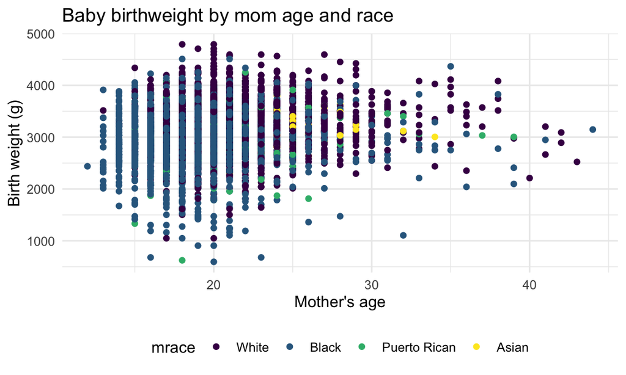

```r
birthweight_df %>%
  ggplot(aes(x = momage, y = bwt, color = mrace)) +
  geom_point() +
   labs(
    title = "Baby birthweight by mom age and race",
    x = "Mother's age",
    y = "Birth weight (g)",
    legend = "race")
```

Birthweight by average number of cigarettes smoked per day during pregnancy

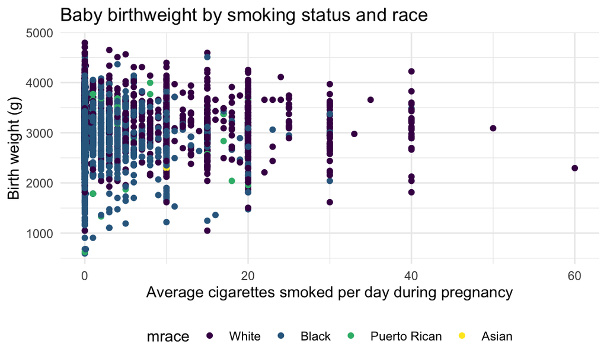

```r
birthweight_df %>%
  ggplot(aes(x = smoken, y = bwt, color = mrace)) +
  geom_point() +
   labs(
    title = "Baby birthweight by smoking status and race",
    x = "Average cigarettes smoked per day during pregnancy",
    y = "Birth weight (g)",
    legend = "race")
```

**3. Fit data**

Based on these plots, it looks like race and mom’s age at birth may have a linear relationship with birth weight, so I will fit a linear model using both of those predictors.

```r
fit = lm(bwt ~ momage + mrace + momage*mrace, data = birthweight_df)
```

```r
fit %>%
  broom::glance()
```

```
## # A tibble: 1 x 12
##   r.squared adj.r.squared sigma statistic  p.value    df  logLik    AIC    BIC
##       <dbl>         <dbl> <dbl>     <dbl>    <dbl> <dbl>   <dbl>  <dbl>  <dbl>
## 1    0.0914        0.0899  489.      62.3 1.08e-85     7 -33041. 66099. 66157.
## # … with 3 more variables: deviance <dbl>, df.residual <int>, nobs <int>
```

```r
fit %>%
  broom::tidy() %>%
  select(term, estimate, p.value) %>%
  mutate(term = str_replace(term, "momage", "Mom's Age at Birth")) %>%
  mutate(term = str_replace(term, "mrace", "Race: ")) %>%
  knitr::kable(digits = 3)
```

| term | estimate | p.value |
| --- | --- | --- |
| (Intercept) | 3118.264 | 0.000 |
| Mom’s Age at Birth | 6.881 | 0.015 |
| Race: Black | -201.435 | 0.021 |
| Race: Puerto Rican | -232.286 | 0.233 |
| Race: Asian | -508.719 | 0.403 |
| Mom’s Age at Birth:Race: Black | -5.113 | 0.231 |
| Mom’s Age at Birth:Race: Puerto Rican | 1.661 | 0.863 |
| Mom’s Age at Birth:Race: Asian | 14.036 | 0.556 |

**4. Add residuals**

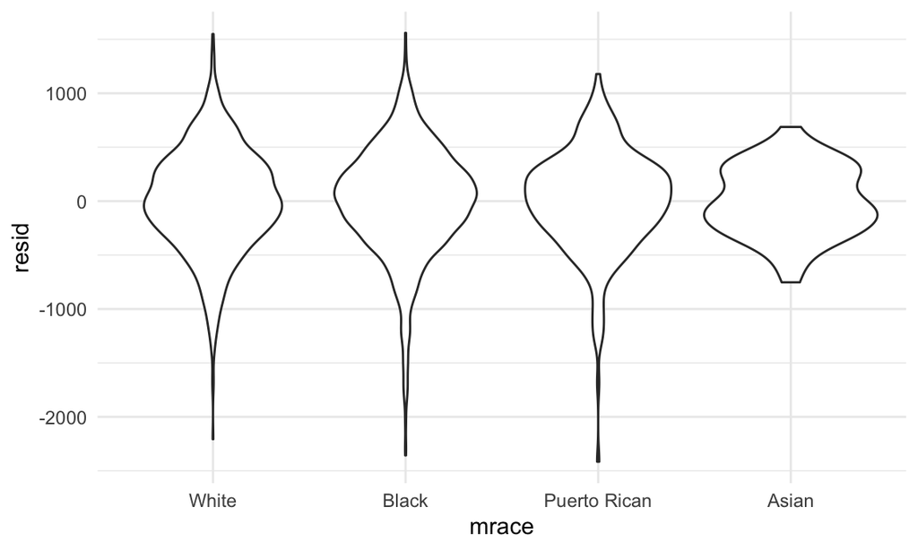

```r
birthweight_df %>%
  modelr::add_residuals(fit) %>%
  ggplot(aes(x = mrace, y = resid)) +
  geom_violin()
```

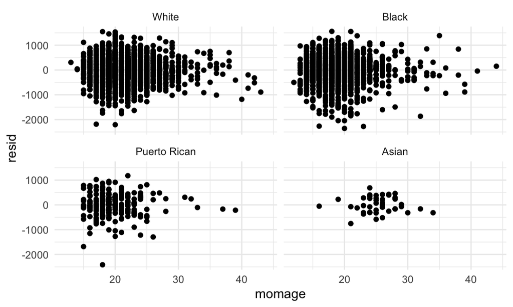

```r
birthweight_df %>%
  modelr::add_residuals(fit) %>%
  ggplot(aes(x = momage, y = resid)) +
  geom_point() +
  facet_wrap(. ~ mrace)
```

The residuals seem to have a fairly consistent distribution, so we will continue with the linear regression model.

```r
modelr::add_predictions(birthweight_df, fit)
```

```
## # A tibble: 4,342 x 21
##    babysex bhead blength   bwt delwt fincome frace gaweeks malform menarche
##    <fct>   <dbl>   <dbl> <dbl> <dbl>   <dbl> <fct>   <dbl> <fct>      <dbl>
##  1 Female     34      51  3629   177      35 White    39.9 Absent        13
##  2 Male       34      48  3062   156      65 Black    25.9 Absent        14
##  3 Female     36      50  3345   148      85 White    39.9 Absent        12
##  4 Male       34      52  3062   157      55 White    40   Absent        14
##  5 Female     34      52  3374   156       5 White    41.6 Absent        13
##  6 Male       33      52  3374   129      55 White    40.7 Absent        12
##  7 Female     33      46  2523   126      96 Black    40.3 Absent        14
##  8 Female     33      49  2778   140       5 White    37.4 Absent        12
##  9 Male       36      52  3515   146      85 White    40.3 Absent        11
## 10 Male       33      50  3459   169      75 Black    40.7 Absent        12
## # … with 4,332 more rows, and 11 more variables: mheight <dbl>, momage <dbl>,
## #   mrace <fct>, parity <dbl>, pnumlbw <dbl>, pnumsga <dbl>, ppbmi <dbl>,
## #   ppwt <dbl>, smoken <dbl>, wtgain <dbl>, pred <dbl>
```

**5. Make plot of modeled residuals against fitted values**

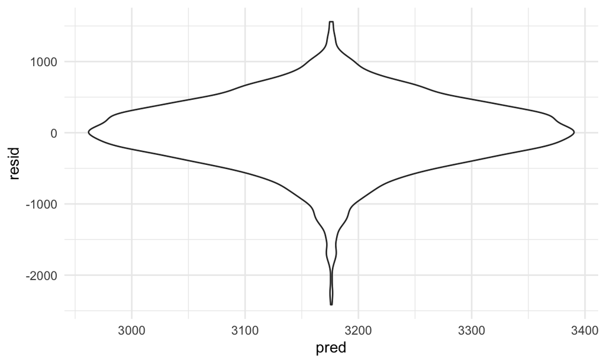

```r
birthweight_df %>%
  modelr::add_residuals(fit) %>%
  modelr::add_predictions(fit) %>%
  ggplot(aes(x = pred, y = resid)) + geom_violin()
```

#### Now I will compare my model to two others

**Model 1: Length at birth and gestational age as predictors (main effects only)**

Look at the data

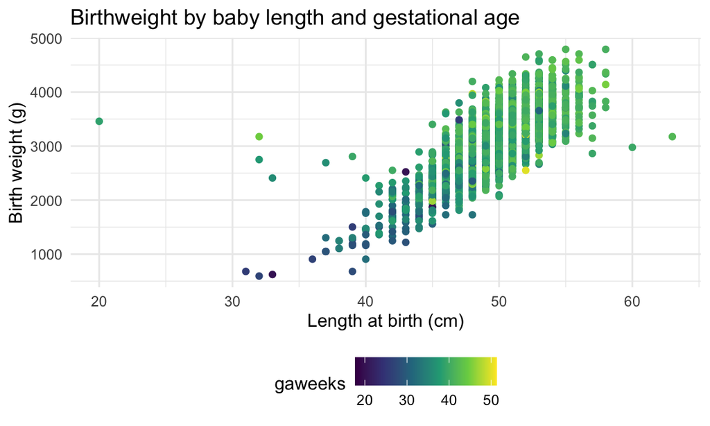

```r
birthweight_df %>%
  ggplot(aes(x = blength, y = bwt, color = gaweeks)) +
  geom_point() +
  labs(
    title = "Birthweight by baby length and gestational age",
    x = "Length at birth (cm)",
    y = "Birth weight (g)")
```

Fit data

```r
fit_2 = lm(bwt ~ blength + gaweeks, data = birthweight_df)
```

```r
fit_2 %>%
  broom::glance()
```

```
## # A tibble: 1 x 12
##   r.squared adj.r.squared sigma statistic p.value    df  logLik    AIC    BIC
##       <dbl>         <dbl> <dbl>     <dbl>   <dbl> <dbl>   <dbl>  <dbl>  <dbl>
## 1     0.577         0.577  333.     2958.       0     2 -31381. 62771. 62796.
## # … with 3 more variables: deviance <dbl>, df.residual <int>, nobs <int>
```

```r
fit_2 %>%
  broom::tidy() %>%
  select(term, estimate, p.value) %>%
  mutate(term = str_replace(term, "blength", "Baby length at birth (cm)")) %>%
  mutate(term = str_replace(term, "gaweeks", "Gestational age (weeks)")) %>%
  knitr::kable(digits = 3)
```

| term | estimate | p.value |
| --- | --- | --- |
| (Intercept) | -4347.667 | 0 |
| Baby length at birth (cm) | 128.556 | 0 |
| Gestational age (weeks) | 27.047 | 0 |

Residuals

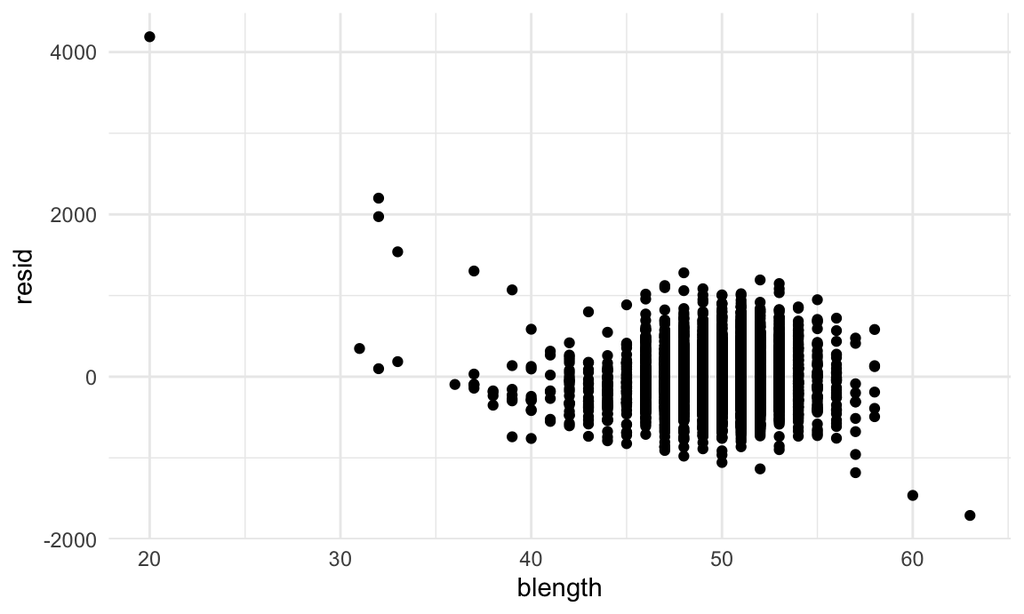

```r
birthweight_df %>%
  modelr::add_residuals(fit_2) %>%
  ggplot(aes(x = blength, y = resid)) +
  geom_point()
```

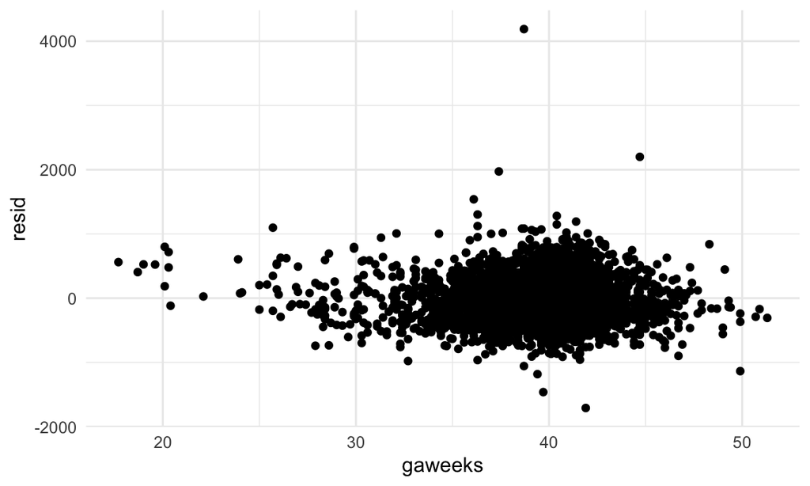

```r
birthweight_df %>%
  modelr::add_residuals(fit_2) %>%
  ggplot(aes(x = gaweeks, y = resid)) +
  geom_point()
```

Predictors

```r
modelr::add_predictions(birthweight_df, fit_2)
```

```
## # A tibble: 4,342 x 21
##    babysex bhead blength   bwt delwt fincome frace gaweeks malform menarche
##    <fct>   <dbl>   <dbl> <dbl> <dbl>   <dbl> <fct>   <dbl> <fct>      <dbl>
##  1 Female     34      51  3629   177      35 White    39.9 Absent        13
##  2 Male       34      48  3062   156      65 Black    25.9 Absent        14
##  3 Female     36      50  3345   148      85 White    39.9 Absent        12
##  4 Male       34      52  3062   157      55 White    40   Absent        14
##  5 Female     34      52  3374   156       5 White    41.6 Absent        13
##  6 Male       33      52  3374   129      55 White    40.7 Absent        12
##  7 Female     33      46  2523   126      96 Black    40.3 Absent        14
##  8 Female     33      49  2778   140       5 White    37.4 Absent        12
##  9 Male       36      52  3515   146      85 White    40.3 Absent        11
## 10 Male       33      50  3459   169      75 Black    40.7 Absent        12
## # … with 4,332 more rows, and 11 more variables: mheight <dbl>, momage <dbl>,
## #   mrace <fct>, parity <dbl>, pnumlbw <dbl>, pnumsga <dbl>, ppbmi <dbl>,
## #   ppwt <dbl>, smoken <dbl>, wtgain <dbl>, pred <dbl>
```

Plot

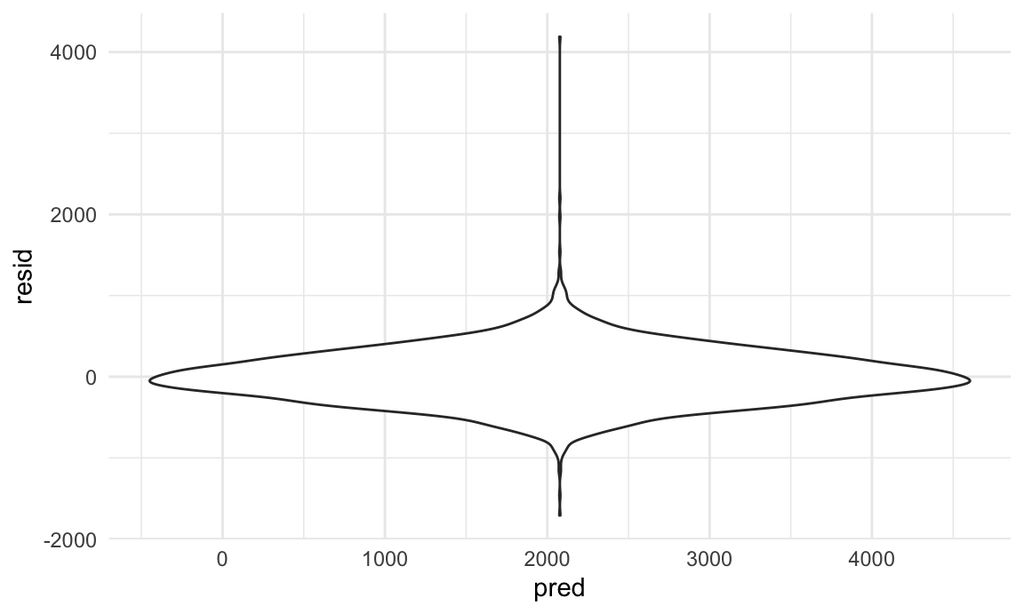

```r
birthweight_df %>%
  modelr::add_residuals(fit_2) %>%
  modelr::add_predictions(fit_2) %>%
  ggplot(aes(x = pred, y = resid)) + geom_violin()
```

**Model 2: Head circumference, length, sex, and all interactions between these three**

Look at the data

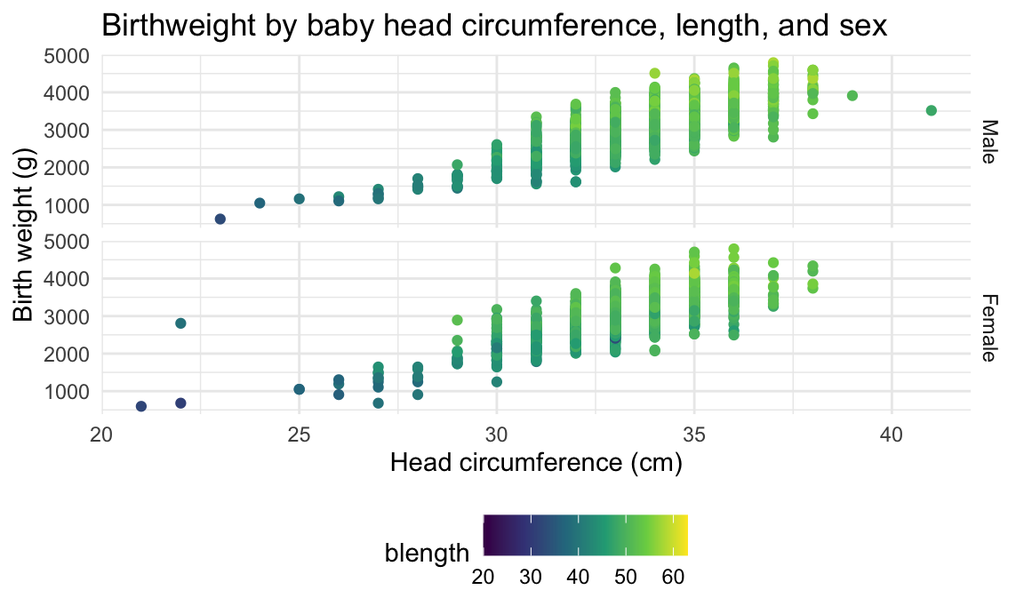

```r
birthweight_df %>%
  group_by(babysex) %>%
  ggplot(aes(x = bhead, y = bwt, color = blength)) +
  geom_point() +
  labs(
    title = "Birthweight by baby head circumference, length, and sex",
    x = "Head circumference (cm)",
    y = "Birth weight (g)") +
  facet_grid(rows = vars(babysex))
```

Fit data

```r
fit_3 = lm(bwt ~ bhead + blength + babysex + bhead*blength + bhead*babysex + blength*babysex + bhead*blength*babysex, data = birthweight_df)
```

```r
fit_3 %>%
  broom::glance()
```

```
## # A tibble: 1 x 12
##   r.squared adj.r.squared sigma statistic p.value    df  logLik    AIC    BIC
##       <dbl>         <dbl> <dbl>     <dbl>   <dbl> <dbl>   <dbl>  <dbl>  <dbl>
## 1     0.685         0.684  288.     1346.       0     7 -30742. 61501. 61559.
## # … with 3 more variables: deviance <dbl>, df.residual <int>, nobs <int>
```

```r
fit_3 %>%
  broom::tidy() %>%
  select(term, estimate, p.value) %>%
  mutate(term = str_replace(term, "blength", "Baby length at birth (cm)")) %>%
  mutate(term = str_replace(term, "bhead", "Baby head circumference (cm)")) %>%
  mutate(term = str_replace(term, "babysex", "")) %>%
  knitr::kable(digits = 3)
```

| term | estimate | p.value |
| --- | --- | --- |
| (Intercept) | -7176.817 | 0.000 |
| Baby head circumference (cm) | 181.796 | 0.000 |
| Baby length at birth (cm) | 102.127 | 0.000 |
| Female | 6374.868 | 0.000 |
| Baby head circumference (cm):Baby length at birth (cm) | -0.554 | 0.478 |
| Baby head circumference (cm):Female | -198.393 | 0.000 |
| Baby length at birth (cm):Female | -123.773 | 0.000 |
| Baby head circumference (cm):Baby length at birth (cm):Female | 3.878 | 0.000 |

Residuals

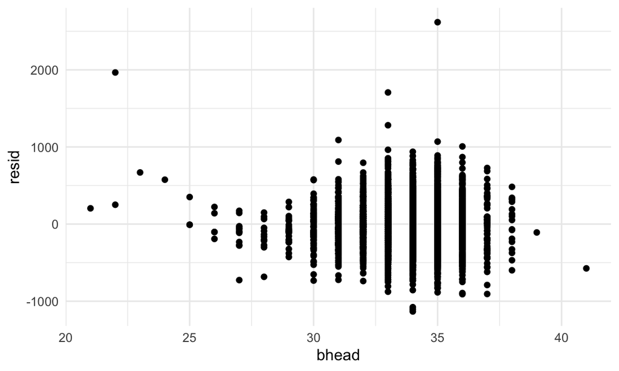

```r
birthweight_df %>%
  modelr::add_residuals(fit_3) %>%
  ggplot(aes(x = bhead, y = resid)) +
  geom_point()
```

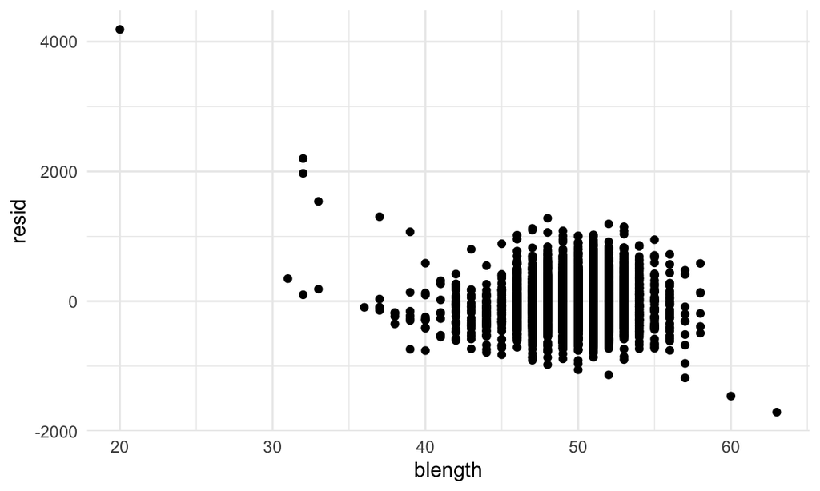

```r
birthweight_df %>%
  modelr::add_residuals(fit_2) %>%
  ggplot(aes(x = blength, y = resid)) +
  geom_point()
```

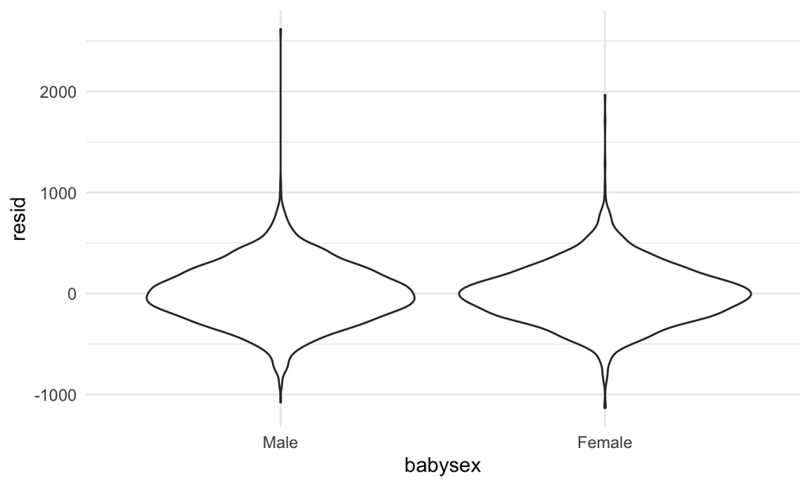

```r
birthweight_df %>%
  modelr::add_residuals(fit_3) %>%
  ggplot(aes(x = babysex, y = resid)) +
  geom_violin()
```

Predictors

```r
modelr::add_predictions(birthweight_df, fit_3)
```

```
## # A tibble: 4,342 x 21
##    babysex bhead blength   bwt delwt fincome frace gaweeks malform menarche
##    <fct>   <dbl>   <dbl> <dbl> <dbl>   <dbl> <fct>   <dbl> <fct>      <dbl>
##  1 Female     34      51  3629   177      35 White    39.9 Absent        13
##  2 Male       34      48  3062   156      65 Black    25.9 Absent        14
##  3 Female     36      50  3345   148      85 White    39.9 Absent        12
##  4 Male       34      52  3062   157      55 White    40   Absent        14
##  5 Female     34      52  3374   156       5 White    41.6 Absent        13
##  6 Male       33      52  3374   129      55 White    40.7 Absent        12
##  7 Female     33      46  2523   126      96 Black    40.3 Absent        14
##  8 Female     33      49  2778   140       5 White    37.4 Absent        12
##  9 Male       36      52  3515   146      85 White    40.3 Absent        11
## 10 Male       33      50  3459   169      75 Black    40.7 Absent        12
## # … with 4,332 more rows, and 11 more variables: mheight <dbl>, momage <dbl>,
## #   mrace <fct>, parity <dbl>, pnumlbw <dbl>, pnumsga <dbl>, ppbmi <dbl>,
## #   ppwt <dbl>, smoken <dbl>, wtgain <dbl>, pred <dbl>
```

Plot

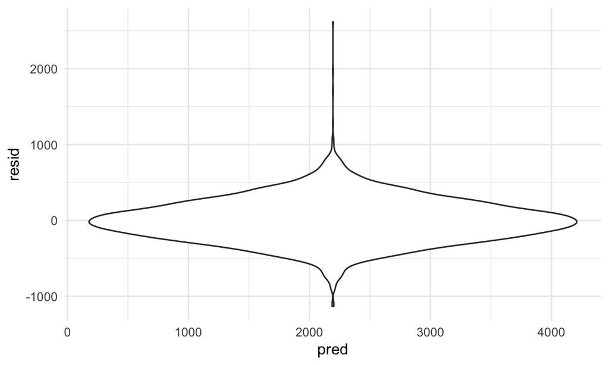

```r
birthweight_df %>%
  modelr::add_residuals(fit_3) %>%
  modelr::add_predictions(fit_3) %>%
  ggplot(aes(x = pred, y = resid)) + geom_violin()
```

**Comparison using cross validation**

```r
cv_df =
  crossv_mc(birthweight_df, 100)
```

```r
cv_df %>% pull(train) %>% .[[1]] %>% as_tibble
```

```
## # A tibble: 3,473 x 20
##    babysex bhead blength   bwt delwt fincome frace gaweeks malform menarche
##    <fct>   <dbl>   <dbl> <dbl> <dbl>   <dbl> <fct>   <dbl> <fct>      <dbl>
##  1 Female     34      51  3629   177      35 White    39.9 Absent        13
##  2 Male       34      48  3062   156      65 Black    25.9 Absent        14
##  3 Female     36      50  3345   148      85 White    39.9 Absent        12
##  4 Male       34      52  3062   157      55 White    40   Absent        14
##  5 Female     34      52  3374   156       5 White    41.6 Absent        13
##  6 Female     33      46  2523   126      96 Black    40.3 Absent        14
##  7 Male       36      52  3515   146      85 White    40.3 Absent        11
##  8 Male       33      50  3459   169      75 Black    40.7 Absent        12
##  9 Female     35      51  3317   130      55 White    43.4 Absent        13
## 10 Male       35      51  3459   146      55 White    39.4 Absent        12
## # … with 3,463 more rows, and 10 more variables: mheight <dbl>, momage <dbl>,
## #   mrace <fct>, parity <dbl>, pnumlbw <dbl>, pnumsga <dbl>, ppbmi <dbl>,
## #   ppwt <dbl>, smoken <dbl>, wtgain <dbl>
```

```r
cv_df =
  cv_df %>%
  mutate(
    train = map(train, as_tibble),
    test = map(test, as_tibble))
```

```r
cv_df =
  cv_df %>%
  mutate(
    fit = map(train, ~lm(bwt ~ momage + mrace, data = .x)),
    fit_2 = map(train, ~lm(bwt ~ blength + gaweeks, data = .x)),
    fit_3 = map(train, ~lm(bwt ~ bhead + blength + babysex + bhead*blength + bhead*babysex + blength*babysex + bhead*blength*babysex, data = .x))) %>%
  mutate(
    rmse_fit = map2_dbl(fit, test, ~rmse(model = .x, data = .y)),
    rmse_fit_2 = map2_dbl(fit_2, test, ~rmse(model = .x, data = .y)),
    rmse_fit_3 = map2_dbl(fit_3, test, ~rmse(model = .x, data = .y)))

modelnames = c("My Model", "Comparison Model 1", "Comparison Model 2")
```

Plot prediction error distribution

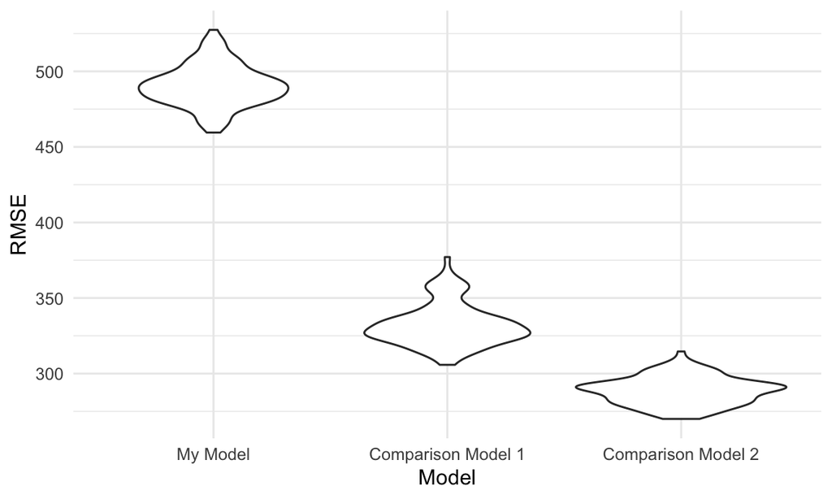

```r
cv_df %>%
  select(starts_with("rmse")) %>%
  pivot_longer(
    everything(),
    names_to = "model",
    values_to = "rmse",
    names_prefix = "rmse_") %>%
  mutate(model = fct_inorder(model)) %>%
  ggplot(aes(x = model, y = rmse)) + geom_violin() +
  labs(
    y = "RMSE",
    x = "Model") +
  scale_x_discrete(labels = modelnames)
```

According to the RMSE distribution of the models, Comparison Model 2, which includes interaction terms, best fits the data. My model appears to have the worst fit.

# Problem 3

This problem uses 2017 Central Park weather data.

First, I’ll load and clean the data:

```r
weather_df =
  rnoaa::meteo_pull_monitors(
    c("USW00094728"),
    var = c("PRCP", "TMIN", "TMAX"),
    date_min = "2017-01-01",
    date_max = "2017-12-31") %>%
  mutate(
    name = recode(id, USW00094728 = "CentralPark_NY"),
    tmin = tmin / 10,
    tmax = tmax / 10) %>%
  select(name, id, everything())
```

Next, I’ll create a simple linear regression model with tmax as the outcome and tmin as a predictor, and test if it’s working.

```r
lm(tmax ~ tmin, data = weather_df) %>%
  broom::tidy() %>%
  knitr::kable(digits = 3)
```

| term | estimate | std.error | statistic | p.value |
| --- | --- | --- | --- | --- |
| (Intercept) | 7.209 | 0.226 | 31.847 | 0 |
| tmin | 1.039 | 0.017 | 61.161 | 0 |

I then estimate bootstrap samples:

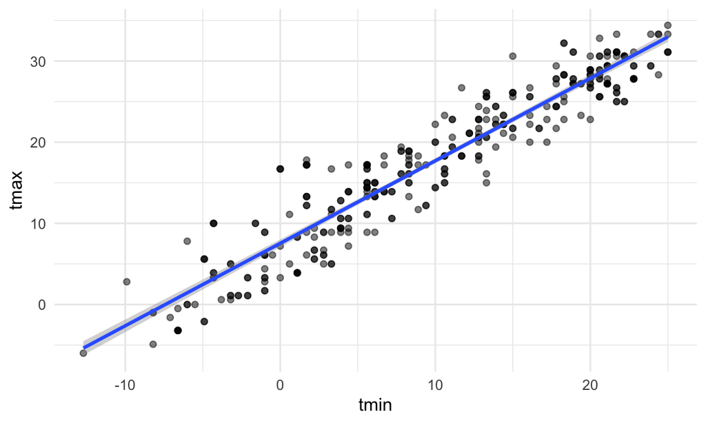

```r
boot_sample = function(df) {
  sample_frac(df, replace = TRUE) %>%
    arrange(tmin)
}

boot_sample(weather_df) %>%
  ggplot(aes(x = tmin, y = tmax)) +
  geom_point(alpha = .5) +
  stat_smooth(method = "lm")
```

```r
boot_straps =
  data_frame(
    strap_number = 1:5000,
    strap_sample = rerun(5000, boot_sample(weather_df))
  )
boot_straps
```

```
## # A tibble: 5,000 x 2
##    strap_number strap_sample
##           <int> <list>
##  1            1 <tibble [365 × 6]>
##  2            2 <tibble [365 × 6]>
##  3            3 <tibble [365 × 6]>
##  4            4 <tibble [365 × 6]>
##  5            5 <tibble [365 × 6]>
##  6            6 <tibble [365 × 6]>
##  7            7 <tibble [365 × 6]>
##  8            8 <tibble [365 × 6]>
##  9            9 <tibble [365 × 6]>
## 10           10 <tibble [365 × 6]>
## # … with 4,990 more rows
```

Then I estimate log(β0∗β1)

```r
bootstrap_result =
  boot_straps %>%
  mutate(
    models = map(strap_sample, ~lm(tmax ~ tmin, data = .x)),
    tidy_results = map(models, broom::tidy),
    glance_results = map(models, broom::glance)) %>%
  unnest(tidy_results, glance_results) %>%
  select(term, estimate, r.squared) %>%
  pivot_wider(
    names_from = term,
    values_from = estimate) %>%
  rename(
    b0 = `(Intercept)`,
    b1 = tmin,
    r2 = r.squared) %>%
  mutate(ln_b0b1 = log(b0*b1)) %>%
  select(r2, ln_b0b1)
bootstrap_result
```

```
## # A tibble: 5,000 x 2
##       r2 ln_b0b1
##    <dbl>   <dbl>
##  1 0.913    1.99
##  2 0.902    2.04
##  3 0.904    2.01
##  4 0.920    1.99
##  5 0.904    2.02
##  6 0.917    2.02
##  7 0.919    2.02
##  8 0.915    2.03
##  9 0.906    2.03
## 10 0.915    1.99
## # … with 4,990 more rows
```

Finally, I will plot the distribution of estimates and identify the 2.5% and 97.5% quantities.

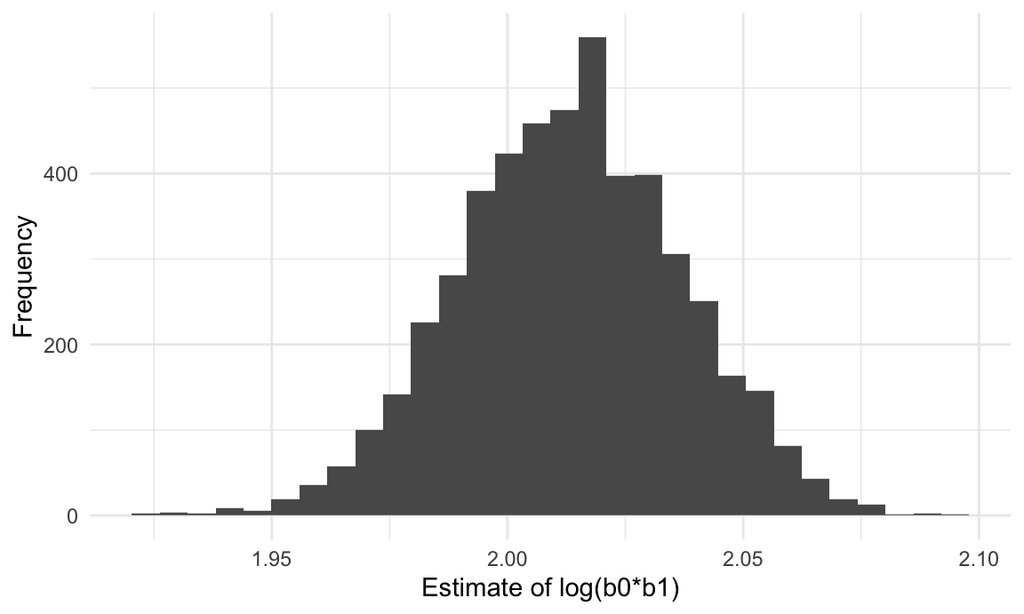

```r
ln_plot =
  bootstrap_result %>%
  ggplot(aes(x = ln_b0b1)) +
  geom_histogram() +
  theme_minimal() +
  labs(
    y = "Frequency",
    x = "Estimate of log(b0*b1)")

ln_plot
```

The 95% confidence interval for log(beta 0 x log beta 1) is (1.97, 2.06).

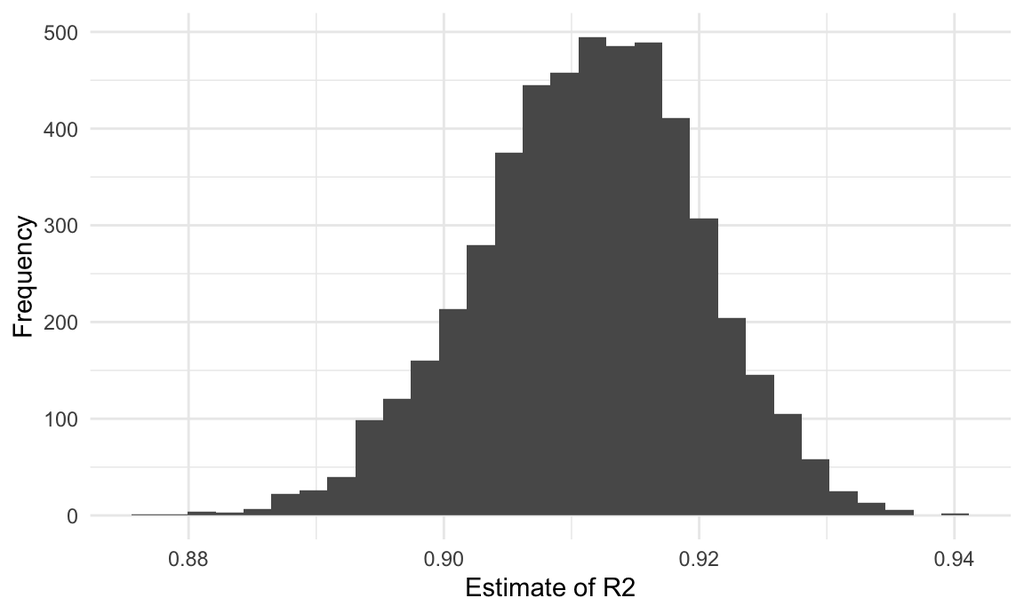

```r
r2_plot =
  bootstrap_result %>%
  ggplot(aes(x = r2)) +
  geom_histogram() +
  theme_minimal() +
  labs(
    y = "Frequency",
    x = "Estimate of R2"
  )

r2_plot
```

The 95% confidence interval of R-squared is (0.89, 0.93).